# From Exposure to Action

### A Data-Driven Career Compass for the AI Era

**Will AI replace human jobs, and which occupations are most at risk of AI-driven displacement, transformation, or augmentation — and what should students and working professionals do about it?**

This notebook is the Phase 1 analysis deliverable. See `docs/From_Exposure_to_Action_Data_Dictionary.xlsx` for the full research framework (typology, hypotheses, target variables, guardrails) and `README.md` for the project overview.

## 0. Setup

```python
import pandas as pd
import numpy as np
import matplotlib.pyplot as plt
import seaborn as sns
from scipy import stats
from IPython.display import display

pd.set_option("display.max_columns", 50)
sns.set_theme(style="whitegrid")
```

## 1. Data acquisition

Run once (or re-run to refresh) before this notebook can execute end to end:

```
python ../src/data_acquisition/fetch_aioe.py
python ../src/data_acquisition/fetch_onet.py
python ../src/data_acquisition/fetch_ilo_genai.py
python ../src/data_acquisition/fetch_bls_crosswalks.py
python ../src/data_acquisition/fetch_gpts_are_gpts.py
python ../src/data_acquisition/fetch_anthropic_economic_index.py
python ../src/data_acquisition/fetch_statcan_canada.py
python ../src/data_acquisition/fetch_bls_oews.py
```

`fetch_bls_crosswalks.py` and `fetch_bls_oews.py` need their source files downloaded manually first (bls.gov blocks scripted downloads) -- see `src/data_acquisition/README.md` for exact filenames/paths. The only source NOT fetched anywhere in this project is OECD's AI Exposure Measure -- investigated and dropped (no downloadable dataset exists, only PDF text), not a pending item.

## 2. Build the master occupation-level dataset

Joins AIOE + O*NET + ILO on occupation code via `src/crosswalks/` and `src/analysis/build_master_dataset.py`. Produces the Composite Exposure Score and a first-pass (provisional) Impact Pattern classification -- see that script's module docstring for the classification rule and its caveats.

```python
import sys
sys.path.insert(0, "../src")
from analysis.build_master_dataset import merge_all, save

# Run once (or re-run after adding a new source) to rebuild data/processed/master_occupations.csv.
# Requires fetch_aioe.py and fetch_onet.py to have been run first (see Section 1).
master = merge_all()
save(master)
master.head()
```

```
Loading AIOE (SOC-level exposure score) ...
```

```
  774 SOC occupations with an AIOE score
Loading O*NET occupation list (O*NET-SOC -> SOC) ...
```

```
  1016 O*NET-SOC occupations
Loading O*NET Job Zones ...
```

```
Loading O*NET skill profile (Essential Skills, Importance ratings) ...
```

```
Loading ILO occupation-level exposure scores (ISCO-08) ...
```

```
  427 ISCO-08 occupations with an ILO score
Loading ILO task-level scores and classifying impact_pattern ...
```

```
  impact_pattern counts: {'Transformation': 208, 'Augmentation': 160, 'Automation': 59}
Building ISCO-08 -> SOC 2018 crosswalk and mapping ILO onto it ...
```

```
  840 SOC 2018 occupations with ILO data after aggregation
Loading GPTs-are-GPTs exposure scores (O*NET-SOC) ...
  798 SOC occupations with a GPTs-are-GPTs score
Loading Anthropic Economic Index usage shares (1P API, O*NET-SOC) ...
```

```
  601 SOC occupations with Anthropic usage data
Loading BLS OEWS employment (multi-year) and computing employment_growth_rate ...
```

```
  831 SOC occupations with a computed employment_growth_rate
Merging AIOE + O*NET + ILO + GPTs-are-GPTs + Anthropic on soc_code ...
```

|  | soc_code | occupation_title | aioe_score | ilo_score | gpts_are_gpts_score | gpts_are_gpts_human_score | composite_exposure_score | impact_pattern | job_zone | anthropic_1p_automation_share | anthropic_1p_augmentation_share | employment_growth_rate | skill__active_learning | skill__active_listening | skill__critical_thinking | skill__learning_strategies | skill__mathematics | skill__monitoring | skill__reading_comprehension | skill__science | skill__speaking | skill__writing | ilo_task_mean | ilo_task_std | tot_emp_2023 | tot_emp_2024 | tot_emp_2025 |
| --- | --- | --- | --- | --- | --- | --- | --- | --- | --- | --- | --- | --- | --- | --- | --- | --- | --- | --- | --- | --- | --- | --- | --- | --- | --- | --- | --- |
| 0 | 11-1011 | Chief Executives | 1.334246 | 0.330000 | 0.507778 | 0.369444 | 0.813478 | Automation | 5.0 | 98.390 | 1.610 | -0.016420 | 3.75 | 4.00 | 4.25 | 3.25 | 3.065 | 3.875 | 4.06 | 1.87 | 4.125 | 4.12 | 0.330000 | 0.080000 | 211230.0 | 211850.0 | 204350.0 |
| 1 | 11-1021 | General and Operations Managers | 0.574877 | 0.401429 | 0.480769 | 0.384615 | 0.696877 | Transformation | 4.0 | 97.190 | 2.810 | -0.000683 | 3.62 | 4.00 | 3.88 | 3.00 | 2.620 | 4.000 | 4.00 | 1.50 | 4.000 | 3.50 | 0.401429 | 0.094286 | 3507810.0 | 3584420.0 | 3503020.0 |
| 2 | 11-1031 | Legislators | NaN | 0.270000 | 0.400000 | 0.516667 | 0.084988 | Augmentation | 4.0 | 95.950 | 4.050 | NaN | NaN | NaN | NaN | NaN | NaN | NaN | NaN | NaN | NaN | NaN | 0.270000 | 0.070000 | 32460.0 | 26510.0 | NaN |
| 3 | 11-2011 | Advertising and Promotions Managers | 1.294387 | 0.390000 | 0.476744 | 0.546512 | 0.902242 | Automation | 4.0 | 91.200 | 8.800 | 0.020156 | 3.38 | 4.12 | 3.88 | 3.00 | 2.880 | 3.500 | 3.75 | 1.50 | 4.120 | 3.75 | 0.390000 | 0.050000 | 20630.0 | 21100.0 | 21470.0 |
| 4 | 11-2021 | Marketing Managers | 1.315032 | 0.410000 | 0.500000 | 0.578125 | 0.993977 | Transformation | 4.0 | 94.365 | 5.635 | 0.035029 | 3.88 | 4.12 | 3.88 | 3.25 | 3.000 | 3.880 | 3.88 | 1.75 | 4.000 | 3.25 | 0.410000 | 0.090000 | 368940.0 | 384980.0 | 395240.0 |

## 3. RQ1 — Consolidated risk ranking across indices

Top/bottom occupations by composite AI exposure. `composite_exposure_score` is the standardized (z-scored) average of the three indices actually joined in `build_master_dataset.py`: AIOE (Felten-Raj-Seamans), ILO's task-based score, and GPTs-are-GPTs (Eloundou et al.) -- each occupation's score uses whichever of the three are available for it, skipping the rest, so coverage varies by occupation. OECD's AI Exposure Measure was investigated and dropped for this project (see `src/data_acquisition/README.md`): no downloadable dataset exists yet, only PDF text in their working paper -- not a pending later pass, a closed dead end unless OECD publishes the raw file.

```python
master = pd.read_csv("../data/processed/master_occupations.csv")

N = 15
CATEGORY_COLORS = {
    "Automation": "#2a78d6",       # blue
    "Transformation": "#eb6834",   # orange
    "Augmentation": "#1baf7a",     # aqua
}
MISSING_COLOR = "#9a9993"  # occupations with no impact_pattern yet

ranked = master.dropna(subset=["composite_exposure_score"]).sort_values(
    "composite_exposure_score", ascending=False
)
print(f"{len(ranked)} of {len(master)} occupations have a composite exposure score.")

display_cols = ["soc_code", "occupation_title", "composite_exposure_score",
                "aioe_score", "ilo_score", "gpts_are_gpts_score", "impact_pattern"]
top_n = ranked.head(N)[display_cols]
bottom_n = ranked.tail(N)[display_cols]

print(f"\nTop {N} highest-exposure occupations:")
display(top_n)
print(f"\nBottom {N} lowest-exposure occupations:")
display(bottom_n)
```

```
934 of 966 occupations have a composite exposure score.

Top 15 highest-exposure occupations:
```

|  | soc_code | occupation_title | composite_exposure_score | aioe_score | ilo_score | gpts_are_gpts_score | impact_pattern |
| --- | --- | --- | --- | --- | --- | --- | --- |
| 632 | 43-9199 | Office and Administrative Support Workers, All... | 2.514839 | NaN | 0.630000 | NaN | Automation |
| 101 | 15-1251 | Computer Programmers | 2.450732 | NaN | 0.570000 | 0.950000 | Automation |
| 98 | 15-1242 | Database Administrators | 2.417788 | NaN | 0.570000 | 0.935484 | Automation |
| 104 | 15-1254 | Web Developers | 2.392827 | NaN | 0.565000 | 0.932692 | Automation |
| 341 | 27-3092 | Court Reporters and Simultaneous Captioners | 2.357891 | NaN | 0.540000 | 0.958333 | Transformation |
| 113 | 15-2099 | Mathematical Science Occupations, All Other | 2.261609 | NaN | 0.570000 | 0.866667 | Transformation |
| 99 | 15-1243 | Database Architects | 2.238612 | NaN | 0.536667 | 0.911247 | Automation |
| 108 | 15-2021 | Mathematicians | 2.175410 | 1.472319 | 0.560000 | 1.000000 | Transformation |
| 103 | 15-1253 | Software Quality Assurance Analysts and Testers | 2.117868 | NaN | 0.525000 | 0.877193 | Automation |
| 102 | 15-1252 | Software Developers | 2.116586 | NaN | 0.530000 | 0.868421 | Automation |
| 590 | 43-4021 | Correspondence Clerks | 2.113190 | 1.149758 | 0.600000 | 0.964286 | Automation |
| 626 | 43-9041 | Insurance Claims and Policy Processing Clerks | 2.044544 | 1.240201 | 0.640000 | 0.833333 | Automation |
| 631 | 43-9111 | Statistical Assistants | 2.008337 | 1.389965 | 0.570000 | 0.891304 | Transformation |
| 588 | 43-3099 | Financial Clerks, All Other | 1.993325 | NaN | 0.560000 | NaN | Automation |
| 582 | 43-3021 | Billing and Posting Clerks and Machine Operators | 1.985570 | 1.333455 | 0.640000 | 0.773810 | Automation |

```
Bottom 15 lowest-exposure occupations:
```

|  | soc_code | occupation_title | composite_exposure_score | aioe_score | ilo_score | gpts_are_gpts_score | impact_pattern |
| --- | --- | --- | --- | --- | --- | --- | --- |
| 785 | 51-3023 | Slaughterers and Meat Packers | -1.507768 | -1.834668 | 0.13 | 0.000000 | Augmentation |
| 686 | 47-3019 | Helpers, Construction Trades, All Other | -1.508268 | NaN | 0.09 | NaN | Augmentation |
| 641 | 45-3011 | Fishers and Related Fishing Workers | -1.513249 | -1.513249 | NaN | NaN | NaN |
| 652 | 47-2022 | Stonemasons | -1.517466 | -1.714759 | 0.11 | 0.000000 | Augmentation |
| 651 | 47-2021 | Brickmasons and Blockmasons | -1.522136 | -1.754340 | 0.09 | 0.038462 | Augmentation |
| 689 | 47-4031 | Fence Erectors | -1.551997 | -1.902113 | 0.09 | 0.051282 | Augmentation |
| 684 | 47-3015 | Helpers--Pipelayers, Plumbers, Pipefitters, an... | -1.555173 | -1.678876 | 0.09 | 0.000000 | Augmentation |
| 659 | 47-2053 | Terrazzo Workers and Finishers | -1.562736 | -1.776065 | 0.10 | 0.000000 | Augmentation |
| 658 | 47-2051 | Cement Masons and Concrete Finishers | -1.563183 | -1.777407 | 0.10 | 0.000000 | Augmentation |
| 325 | 27-2031 | Dancers | -1.605607 | -2.669758 | 0.19 | 0.020833 | Transformation |
| 711 | 47-5061 | Roof Bolters, Mining | -1.618518 | -1.618518 | NaN | NaN | NaN |
| 685 | 47-3016 | Helpers--Roofers | -1.628288 | -1.898220 | 0.09 | 0.000000 | Augmentation |
| 680 | 47-3011 | Helpers--Brickmasons, Blockmasons, Stonemasons... | -1.642978 | -1.942290 | 0.09 | 0.000000 | Augmentation |
| 683 | 47-3014 | Helpers--Painters, Paperhangers, Plasterers, a... | -1.677161 | -2.044840 | 0.09 | 0.000000 | Augmentation |
| 443 | 31-1015 | Orderlies | -1.679232 | -1.679232 | NaN | NaN | NaN |

```python
# Do the two available indices agree on which occupations are exposed?
# AIOE (Felten/Raj/Seamans, LLM-linguistic-task-based) and ILO (Gmyrek et al.,
# GPT-4o/Gemini task-rating-based) use different methodologies, so agreement here
# is informative even with just these two -- a low/insignificant rho would say the
# indices disagree more than expected, which matters as much as a high one.
paired = master.dropna(subset=["aioe_score", "ilo_score"])
rho, p_value = stats.spearmanr(paired["aioe_score"], paired["ilo_score"])
print(f"Spearman rho (AIOE vs ILO), n={len(paired)}: {rho:.3f} (p={p_value:.2e})")

print("\nimpact_pattern distribution (occupations with a value):")
print(master["impact_pattern"].value_counts())
print(f"({master['impact_pattern'].isna().sum()} occupations have no impact_pattern -- "
      "no ILO task-level match, see build_master_dataset.py)")
```

```
Spearman rho (AIOE vs ILO), n=680: 0.805 (p=4.86e-156)

impact_pattern distribution (occupations with a value):
impact_pattern
Transformation    401
Augmentation      339
Automation        100
Name: count, dtype: int64
(126 occupations have no impact_pattern -- no ILO task-level match, see build_master_dataset.py)
```

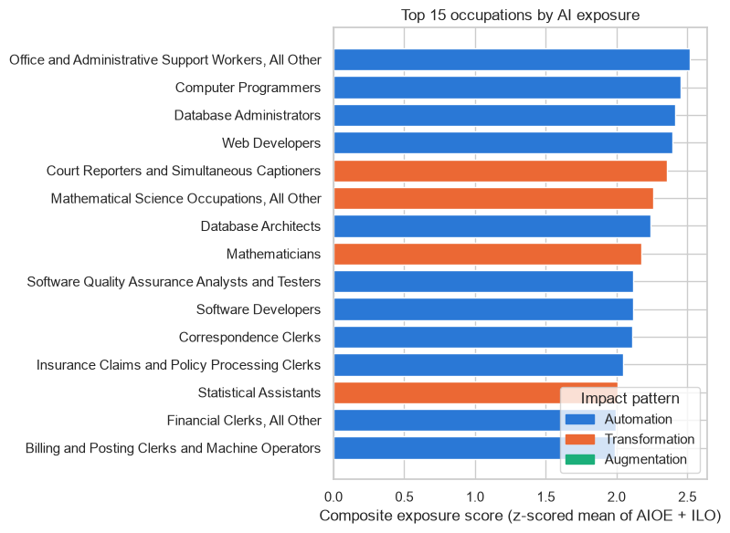

```python
fig, ax = plt.subplots(figsize=(8, 6))
plot_df = top_n.iloc[::-1]  # reverse so the highest-exposure occupation plots on top
colors = plot_df["impact_pattern"].map(CATEGORY_COLORS).fillna(MISSING_COLOR)
ax.barh(plot_df["occupation_title"], plot_df["composite_exposure_score"], color=colors)
ax.set_xlabel("Composite exposure score (z-scored mean of AIOE + ILO)")
ax.set_title(f"Top {N} occupations by AI exposure")
handles = [plt.Rectangle((0, 0), 1, 1, color=c) for c in CATEGORY_COLORS.values()]
ax.legend(handles, CATEGORY_COLORS.keys(), title="Impact pattern", loc="lower right")
plt.tight_layout()
plt.show()
```

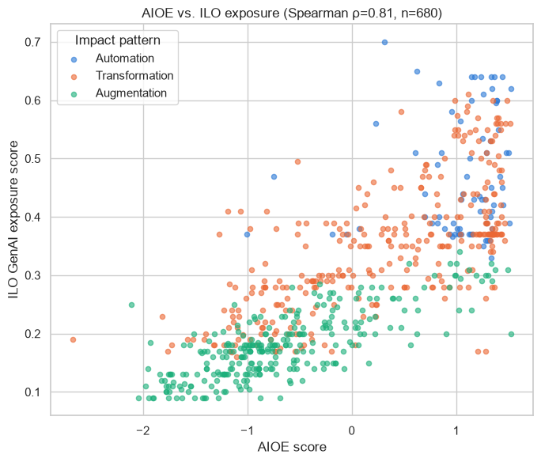

```python
fig, ax = plt.subplots(figsize=(7, 6))
for pattern, color in CATEGORY_COLORS.items():
    subset = paired[paired["impact_pattern"] == pattern]
    ax.scatter(subset["aioe_score"], subset["ilo_score"], s=20, alpha=0.6,
               color=color, label=pattern)
no_pattern = paired[paired["impact_pattern"].isna()]
if len(no_pattern):
    ax.scatter(no_pattern["aioe_score"], no_pattern["ilo_score"], s=20, alpha=0.4,
               color=MISSING_COLOR, label="(no impact_pattern)")
ax.set_xlabel("AIOE score")
ax.set_ylabel("ILO GenAI exposure score")
ax.set_title(f"AIOE vs. ILO exposure (Spearman ρ={rho:.2f}, n={len(paired)})")
ax.legend(title="Impact pattern")
plt.tight_layout()
plt.show()
```

**A caveat on ties in the ranking:** the ISCO-08 -> SOC 2018 crosswalk is many-to-many, so several distinct SOC titles here can trace back to the very same ISCO-08 unit group and inherit its exact `ilo_score`. When one of those tied occupations also has no AIOE coverage (`aioe_score` is NaN), its `composite_exposure_score` is driven entirely by that one shared ILO value -- so an exact tie in the top/bottom list reflects a shared ISCO parent, not two independent methodologies agreeing on that specific occupation. Worth noting explicitly in the write-up rather than presenting every entry as independently confirmed.

## 4. RQ2 -- Automation vs. Transformation vs. Augmentation

`impact_pattern` in the master table is now populated from ILO's task-level score variance (see `build_master_dataset.py`'s module docstring for the classification rule). This is a first-pass, provisional heuristic -- cross-check it here against the Anthropic Economic Index's own automation/augmentation usage split once that source is added (tests H2).

```python
# RQ2 cross-check: does the ILO-task-variance-based impact_pattern label
# (Automation/Transformation/Augmentation) actually line up with how people
# are using Claude on those occupations in the real world (Anthropic
# Economic Index's own automation/augmentation usage split)? This is a
# genuine cross-check of a provisional heuristic against an independent
# real-usage signal -- distinct from RQ5, which correlated the CONTINUOUS
# composite_exposure_score; this looks at the CATEGORICAL impact_pattern
# groups directly.

rq2 = master.dropna(subset=["impact_pattern"]).copy()

group_summary = rq2.groupby("impact_pattern").agg(
    n_occupations=("soc_code", "count"),
    n_with_anthropic_data=("anthropic_1p_automation_share", "count"),
    mean_automation_share=("anthropic_1p_automation_share", "mean"),
    mean_augmentation_share=("anthropic_1p_augmentation_share", "mean"),
).round(2)
group_summary = group_summary.reindex(["Automation", "Transformation", "Augmentation"])
print("=== Anthropic usage shares by impact_pattern group ===")
display(group_summary)
```

```
=== Anthropic usage shares by impact_pattern group ===
```

| impact_pattern | n_occupations | n_with_anthropic_data | mean_automation_share | mean_augmentation_share |
| --- | --- | --- | --- | --- |
| Automation | 100 | 96 | 93.18 | 6.82 |
| Transformation | 401 | 326 | 89.51 | 10.49 |
| Augmentation | 339 | 174 | 93.63 | 6.37 |

```python
order = ["Automation", "Transformation", "Augmentation"]
groups_automation = [rq2.loc[rq2["impact_pattern"] == p, "anthropic_1p_automation_share"].dropna() for p in order]
groups_augmentation = [rq2.loc[rq2["impact_pattern"] == p, "anthropic_1p_augmentation_share"].dropna() for p in order]

# Kruskal-Wallis (non-parametric, no normality assumption -- same reasoning
# as this project's use of Spearman correlation elsewhere) tests whether the
# three impact_pattern groups' usage-share distributions differ at all.
if all(len(g) >= 3 for g in groups_automation):
    h_auto, p_auto = stats.kruskal(*groups_automation)
    print(f"Kruskal-Wallis, anthropic_1p_automation_share across impact_pattern groups: H={h_auto:.2f}, p={p_auto:.3g}")
else:
    print("Not enough data in one or more groups for Kruskal-Wallis (automation_share).")

if all(len(g) >= 3 for g in groups_augmentation):
    h_aug, p_aug = stats.kruskal(*groups_augmentation)
    print(f"Kruskal-Wallis, anthropic_1p_augmentation_share across impact_pattern groups: H={h_aug:.2f}, p={p_aug:.3g}")
else:
    print("Not enough data in one or more groups for Kruskal-Wallis (augmentation_share).")
```

```
Kruskal-Wallis, anthropic_1p_automation_share across impact_pattern groups: H=15.83, p=0.000365
Kruskal-Wallis, anthropic_1p_augmentation_share across impact_pattern groups: H=15.83, p=0.000365
```

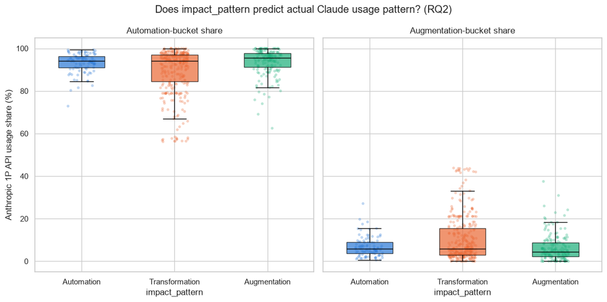

```python
fig, axes = plt.subplots(1, 2, figsize=(12, 6), sharey=True)
rng = np.random.default_rng(0)

for ax, col, title in zip(
    axes,
    ["anthropic_1p_automation_share", "anthropic_1p_augmentation_share"],
    ["Automation-bucket share", "Augmentation-bucket share"],
):
    data_by_group = [rq2.loc[rq2["impact_pattern"] == p, col].dropna() for p in order]
    bp = ax.boxplot(data_by_group, tick_labels=order, patch_artist=True, showfliers=False, widths=0.5)
    for patch, pattern in zip(bp["boxes"], order):
        patch.set_facecolor(CATEGORY_COLORS[pattern])
        patch.set_alpha(0.7)
    for median_line in bp["medians"]:
        median_line.set_color("black")
    for i, (pattern, series) in enumerate(zip(order, data_by_group), start=1):
        jitter = rng.uniform(-0.15, 0.15, size=len(series))
        ax.scatter(
            np.full(len(series), i) + jitter, series, color=CATEGORY_COLORS[pattern],
            alpha=0.3, s=15, edgecolor="none",
        )
    ax.set_title(title)
    ax.set_xlabel("impact_pattern")

axes[0].set_ylabel("Anthropic 1P API usage share (%)")
fig.suptitle("Does impact_pattern predict actual Claude usage pattern? (RQ2)")
plt.tight_layout()
plt.savefig("../outputs/figures/rq2_impact_pattern_vs_anthropic_usage.png", dpi=150)
plt.show()
```

**Reading this section:** `impact_pattern` is a provisional heuristic derived from ILO's task-level score variance (see `build_master_dataset.py`'s docstring) -- it was never fit or validated against real usage data. This cross-check asks a direct question: do occupations labeled "Automation" actually show a higher real-world automation-bucket usage share than occupations labeled "Augmentation" or "Transformation"?

**Real result:** Kruskal-Wallis H = 15.83, p = 0.000365 (both shares -- automation and augmentation -- give the same statistic, since the two are near-complementary within a row). The three groups do differ, but not in the naively-expected direction. Group means for `anthropic_1p_automation_share`:

| impact_pattern | n (with usage data) | automation share | augmentation share |
| --- | --- | --- | --- |
| Automation | 96 | 93.18% | 6.82% |
| Augmentation | 174 | 93.63% | 6.37% |
| Transformation | 326 | 89.51% | 10.49% |

"Automation" and "Augmentation" occupations are nearly indistinguishable on this real-usage measure -- both sit around 93% automation-style usage. "Transformation" is the actual outlier: a *lower* automation share and *higher* augmentation share than either of the other two labels, the opposite of what the label's name would suggest.

This is a genuine finding about this heuristic's current limits, not a bug -- worth stating plainly in the write-up rather than smoothed over, and consistent with RQ5's finding that the continuous `composite_exposure_score` also didn't correlate with automation-style usage in the naively-expected direction. Read together, RQ2 and RQ5 both point the same way: this project's theoretical exposure typology does not yet predict how AI is actually being used against these occupations in practice.

## 5. RQ3 — Task-level vulnerability

Which tasks within an occupation carry the highest ILO exposure scores.

```python
# RQ3: which TASKS within an occupation carry the highest ILO exposure
# scores? Uses load_ilo_task_detail() -- genuine task-level granularity
# (score_2025 varies per task), NOT the occupation-level aggregate
# (mean_score_2025) used elsewhere in this notebook. Standalone /
# illustrative, same pattern as the Canada appendix -- not joined into
# the master table, since task-level rows don't fit a one-row-per-
# occupation table.

from analysis.build_master_dataset import load_ilo_task_detail

task_detail = load_ilo_task_detail()
occ_scores = task_detail.drop_duplicates("isco_code")[
    ["isco_code", "occupation_title", "occupation_mean_score_2025"]
]
top_occupations = occ_scores.sort_values("occupation_mean_score_2025", ascending=False).head(6)
print("=== Top occupations by ILO mean exposure score (2025) -- task breakdown below ===")
display(top_occupations)
```

```
=== Top occupations by ILO mean exposure score (2025) -- task breakdown below ===
```

|  | isco_code | occupation_title | occupation_mean_score_2025 |
| --- | --- | --- | --- |
| 1676 | 4132 | Data Entry Clerks | 0.70 |
| 1669 | 4131 | Typists and Word Processing Operators | 0.65 |
| 1756 | 4312 | Statistical, Finance and Insurance Clerks | 0.64 |
| 1751 | 4311 | Accounting and Bookkeeping Clerks | 0.64 |
| 1812 | 4419 | Clerical Support Workers Not Elsewhere Classified | 0.63 |
| 1373 | 3311 | Securities and Finance Dealers and Brokers | 0.63 |

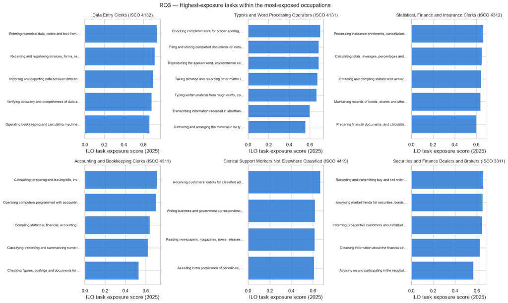

```python
n_panels = len(top_occupations)
ncols = 3
nrows = -(-n_panels // ncols)  # ceil
fig, axes = plt.subplots(nrows, ncols, figsize=(16, 5 * nrows))
axes = np.atleast_1d(axes).flatten()

for ax, (_, row) in zip(axes, top_occupations.iterrows()):
    occ_tasks = task_detail[task_detail["isco_code"] == row["isco_code"]].sort_values(
        "task_score_2025", ascending=True
    ).tail(8)
    labels = [d[:45] + ("\u2026" if len(d) > 45 else "") for d in occ_tasks["task_description"]]
    ax.barh(labels, occ_tasks["task_score_2025"], color="#2a78d6", alpha=0.85)
    ax.set_title(f"{row['occupation_title']} (ISCO {row['isco_code']})", fontsize=10)
    ax.set_xlabel("ILO task exposure score (2025)")
    ax.tick_params(axis="y", labelsize=8)

for ax in axes[n_panels:]:
    ax.axis("off")

fig.suptitle("RQ3 \u2014 Highest-exposure tasks within the most-exposed occupations", fontsize=13)
plt.tight_layout()
plt.savefig("../outputs/figures/rq3_task_level_vulnerability.png", dpi=150)
plt.show()
```

**Reading this section:** these are the 6 occupations with the highest *occupation-level* ILO score, each broken down into its own *task-level* scores (top 8 tasks shown, longest bar = most exposed task within that occupation). Within any one occupation, tasks typically span a real range -- that spread is exactly what feeds this project's `impact_pattern` classification (high task-to-task variance → "Transformation"; low variance + high mean → "Automation"; low variance + low/mid mean → "Augmentation").

Task descriptions are truncated for display; the full text is available from `load_ilo_task_detail()`'s `task_description` column if a specific task needs to be quoted in the write-up. These scores are ILO's own 2025 GPT-4o/Gemini-updated estimates -- treat individual task rankings as illustrative of *within-occupation* spread, not as precise, individually-validated measurements.

## 6. RQ4 — Protective skill profile

Compare O*NET skill/ability distributions between high- and low-exposure occupation groups (tests H4).

```python
# RQ4: which O*NET skills/abilities are more (or less) common in
# high-exposure vs. low-exposure occupations -- a "protective skill
# profile" a person could read as: which skills correlate with
# occupations that are currently LESS exposed on the theoretical indices?
# Splits on composite_exposure_score TERTILES (top third = high, bottom
# third = low) rather than impact_pattern, since impact_pattern is
# categorical/provisional and exposure here needs a continuous ranking to
# split cleanly into comparison groups.

skill_cols = [c for c in master.columns if c.startswith("skill__")]

rq4 = master.dropna(subset=["composite_exposure_score"]).copy()
low_cut = rq4["composite_exposure_score"].quantile(1 / 3)
high_cut = rq4["composite_exposure_score"].quantile(2 / 3)
rq4["exposure_group"] = np.select(
    [rq4["composite_exposure_score"] <= low_cut, rq4["composite_exposure_score"] >= high_cut],
    ["Low exposure", "High exposure"],
    default="Mid (excluded)",
)
rq4_ends = rq4[rq4["exposure_group"] != "Mid (excluded)"]
print(
    f"{len(rq4_ends)} occupations in the low/high exposure comparison "
    f"({(rq4_ends['exposure_group'] == 'Low exposure').sum()} low, "
    f"{(rq4_ends['exposure_group'] == 'High exposure').sum()} high)"
)

# Mann-Whitney U per skill (non-parametric two-group comparison, same
# reasoning as Kruskal-Wallis/Spearman used elsewhere in this notebook),
# plus the mean difference so the table is readable without staring at
# only p-values.
rows = []
for col in skill_cols:
    low_vals = rq4_ends.loc[rq4_ends["exposure_group"] == "Low exposure", col].dropna()
    high_vals = rq4_ends.loc[rq4_ends["exposure_group"] == "High exposure", col].dropna()
    if len(low_vals) < 3 or len(high_vals) < 3:
        continue
    u, p = stats.mannwhitneyu(high_vals, low_vals, alternative="two-sided")
    rows.append({
        "skill": col.replace("skill__", "").replace("_", " "),
        "mean_low_exposure": round(low_vals.mean(), 2),
        "mean_high_exposure": round(high_vals.mean(), 2),
        "diff_high_minus_low": round(high_vals.mean() - low_vals.mean(), 2),
        "mannwhitney_p": p,
    })
skill_diff = pd.DataFrame(rows).sort_values("diff_high_minus_low")
print("\n=== Skill importance: high-exposure minus low-exposure occupations ===")
display(skill_diff)
```

```
624 occupations in the low/high exposure comparison (312 low, 312 high)

=== Skill importance: high-exposure minus low-exposure occupations ===
```

|  | skill | mean_low_exposure | mean_high_exposure | diff_high_minus_low | mannwhitney_p |
| --- | --- | --- | --- | --- | --- |
| 5 | monitoring | 3.07 | 3.34 | 0.28 | 1.803373e-17 |
| 7 | science | 1.50 | 2.01 | 0.52 | 7.894327e-06 |
| 4 | mathematics | 2.19 | 2.85 | 0.65 | 3.954449e-32 |
| 2 | critical thinking | 3.10 | 3.75 | 0.66 | 1.071513e-55 |
| 3 | learning strategies | 2.34 | 3.03 | 0.69 | 5.638328e-42 |
| 0 | active learning | 2.65 | 3.42 | 0.77 | 1.429323e-57 |
| 1 | active listening | 3.11 | 3.90 | 0.79 | 2.401895e-72 |
| 8 | speaking | 3.04 | 3.87 | 0.83 | 3.358871e-70 |
| 6 | reading comprehension | 2.87 | 3.90 | 1.03 | 9.904948e-81 |
| 9 | writing | 2.51 | 3.66 | 1.15 | 1.288793e-79 |

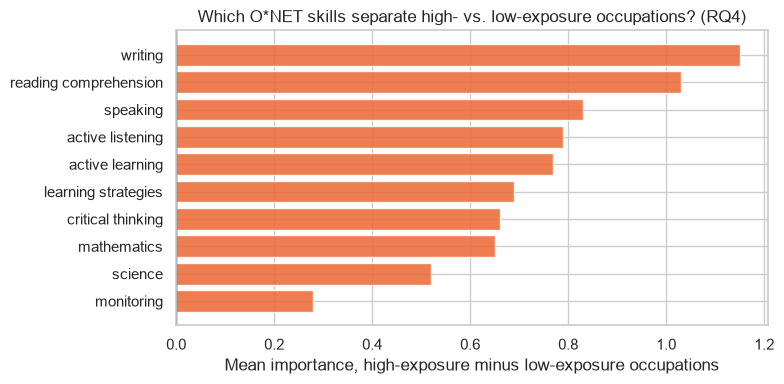

```python
fig, ax = plt.subplots(figsize=(8, max(4, 0.4 * len(skill_diff))))
colors = ["#2a78d6" if v < 0 else "#eb6834" for v in skill_diff["diff_high_minus_low"]]
ax.barh(skill_diff["skill"], skill_diff["diff_high_minus_low"], color=colors, alpha=0.85)
ax.axvline(0, color="#3d3d3a", linewidth=1)
ax.set_xlabel("Mean importance, high-exposure minus low-exposure occupations")
ax.set_title("Which O*NET skills separate high- vs. low-exposure occupations? (RQ4)")
plt.tight_layout()
plt.savefig("../outputs/figures/rq4_skill_profile_diff.png", dpi=150)
plt.show()
```

```python
# Most "protective" skills: largest NEGATIVE diff = most associated with
# LOW-exposure occupations (i.e. more important where AI exposure is lower).
most_protective = skill_diff.sort_values("diff_high_minus_low").head(5)
most_exposed_associated = skill_diff.sort_values("diff_high_minus_low", ascending=False).head(5)
print("=== Skills most associated with LOW-exposure occupations (candidate 'protective' skills) ===")
display(most_protective)
print("\n=== Skills most associated with HIGH-exposure occupations ===")
display(most_exposed_associated)
```

```
=== Skills most associated with LOW-exposure occupations (candidate 'protective' skills) ===
```

|  | skill | mean_low_exposure | mean_high_exposure | diff_high_minus_low | mannwhitney_p |
| --- | --- | --- | --- | --- | --- |
| 5 | monitoring | 3.07 | 3.34 | 0.28 | 1.803373e-17 |
| 7 | science | 1.50 | 2.01 | 0.52 | 7.894327e-06 |
| 4 | mathematics | 2.19 | 2.85 | 0.65 | 3.954449e-32 |
| 2 | critical thinking | 3.10 | 3.75 | 0.66 | 1.071513e-55 |
| 3 | learning strategies | 2.34 | 3.03 | 0.69 | 5.638328e-42 |

```
=== Skills most associated with HIGH-exposure occupations ===
```

|  | skill | mean_low_exposure | mean_high_exposure | diff_high_minus_low | mannwhitney_p |
| --- | --- | --- | --- | --- | --- |
| 9 | writing | 2.51 | 3.66 | 1.15 | 1.288793e-79 |
| 6 | reading comprehension | 2.87 | 3.90 | 1.03 | 9.904948e-81 |
| 8 | speaking | 3.04 | 3.87 | 0.83 | 3.358871e-70 |
| 1 | active listening | 3.11 | 3.90 | 0.79 | 2.401895e-72 |
| 0 | active learning | 2.65 | 3.42 | 0.77 | 1.429323e-57 |

**Reading this section:** this compares O*NET skill-importance ratings between occupations in the top third and bottom third of `composite_exposure_score` (n = 312 low-exposure, 312 high-exposure occupations). It does not claim a skill *causes* lower exposure, only whether it's rated more or less important in occupations that currently score lower on the theoretical indices.

**Real result -- read carefully:** all 10 tested skills came back *positively* associated with high exposure, none negatively. There is no "protective skill" in this result:

| skill | diff (high − low exposure) | p-value |
| --- | --- | --- |
| Monitoring | +0.28 | 1.8e-17 |
| Science | +0.52 | 7.9e-06 |
| Mathematics | +0.65 | 3.95e-32 |
| Critical Thinking | +0.66 | 1.07e-55 |
| Learning Strategies | +0.69 | 5.6e-42 |
| Active Learning | +0.77 | 1.43e-57 |
| Active Listening | +0.79 | 2.4e-72 |
| Speaking | +0.83 | 3.36e-70 |
| Reading Comprehension | +1.03 | 9.9e-81 |
| Writing | +1.15 | 1.29e-79 |

The "most protective" table above is really just the smallest-positive-diff skills, not genuinely protective ones -- worth being explicit about that distinction in the write-up.

**Why, most likely:** this project's `Essential Skills.xlsx` fetch only covers O*NET's "Basic Skills" category (the 10 skills above) -- confirmed by direct inspection of the real file's column list. It does not include O*NET's separate "Cross-Functional Skills" category (Complex Problem Solving, Technical Skills, Resource Management Skills, Social Skills, and others), which live in different O*NET source files (`Skills.xlsx` / `Abilities.xlsx`) not currently fetched by this project. Basic Skills skew toward the kind of cognitive/communication work that's common in exactly the white-collar, higher-exposure occupations this dataset flags -- so this result is very likely a scope limitation of which skills were fetched, not evidence that no protective skill exists anywhere in O*NET's taxonomy.

**Flagged as a known limitation:** a genuine "protective skill profile" analysis would need to fetch and join O*NET's Cross-Functional Skills and Abilities files first. That's a documented next step, not pursued in this pass -- the honest finding here is "no protective skill found among the 10 Basic Skills tested," not "no protective skill exists."

## 7. RQ5 — Theoretical exposure vs. realized labor-market impact

```python
# RQ5: does the THEORETICAL composite exposure score line up with what's
# already visible in the real labor market? Two independent real-world
# signals: (1) BLS OEWS employment growth 2023->2025 (does employment
# already show contraction in high-exposure occupations?), and (2) the
# Anthropic Economic Index's actual usage share (are people already using
# Claude to automate/augment the same occupations the theoretical indices
# flag as exposed?). Associative only, per this project's guardrails -- not
# a forecast, and BLS OEWS growth compresses many macro factors (not just
# AI) into one number over a short 2-year window.

rq5 = master.dropna(subset=["composite_exposure_score"]).copy()


def spearman_report(df, x_col, y_col, label):
    sub = df.dropna(subset=[x_col, y_col])
    if len(sub) < 3:
        print(f"{label}: not enough overlapping data (n={len(sub)})")
        return None
    rho, p = stats.spearmanr(sub[x_col], sub[y_col])
    print(f"{label}: rho={rho:.3f}, p={p:.3g}, n={len(sub)}")
    return rho, p, len(sub)


print("=== RQ5 correlations: composite_exposure_score vs. real-world signals ===\n")
growth_result = spearman_report(
    rq5, "composite_exposure_score", "employment_growth_rate",
    "composite_exposure_score vs. employment_growth_rate (BLS OEWS 2023->2025)",
)
auto_result = spearman_report(
    rq5, "composite_exposure_score", "anthropic_1p_automation_share",
    "composite_exposure_score vs. anthropic_1p_automation_share",
)
aug_result = spearman_report(
    rq5, "composite_exposure_score", "anthropic_1p_augmentation_share",
    "composite_exposure_score vs. anthropic_1p_augmentation_share",
)
```

```
=== RQ5 correlations: composite_exposure_score vs. real-world signals ===

composite_exposure_score vs. employment_growth_rate (BLS OEWS 2023->2025): rho=0.025, p=0.47, n=817
composite_exposure_score vs. anthropic_1p_automation_share: rho=-0.230, p=1.25e-08, n=598
composite_exposure_score vs. anthropic_1p_augmentation_share: rho=0.230, p=1.25e-08, n=598
```

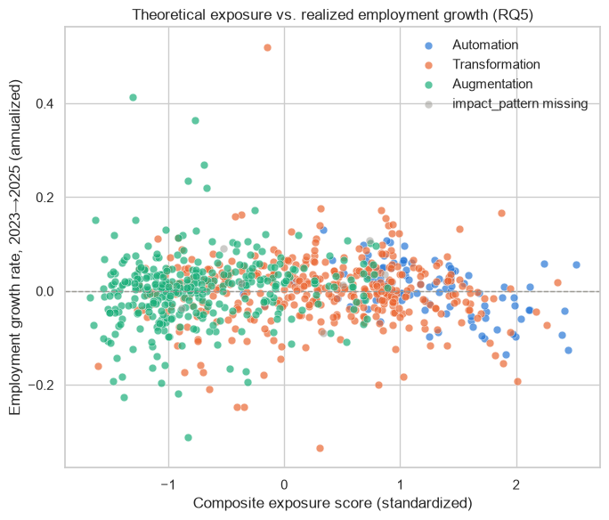

```python
fig, ax = plt.subplots(figsize=(7, 6))
for pattern, color in CATEGORY_COLORS.items():
    subset = rq5[(rq5["impact_pattern"] == pattern) & rq5["employment_growth_rate"].notna()]
    ax.scatter(
        subset["composite_exposure_score"], subset["employment_growth_rate"],
        label=pattern, color=color, alpha=0.7, edgecolor="white", linewidth=0.4, s=40,
    )
missing = rq5[rq5["impact_pattern"].isna() & rq5["employment_growth_rate"].notna()]
if len(missing):
    ax.scatter(
        missing["composite_exposure_score"], missing["employment_growth_rate"],
        label="impact_pattern missing", color=MISSING_COLOR, alpha=0.5,
        edgecolor="white", linewidth=0.4, s=40,
    )
ax.axhline(0, color="#9a9993", linewidth=1, linestyle="--")
ax.set_xlabel("Composite exposure score (standardized)")
ax.set_ylabel("Employment growth rate, 2023\u21922025 (annualized)")
ax.set_title("Theoretical exposure vs. realized employment growth (RQ5)")
ax.legend(frameon=False, loc="best")
plt.tight_layout()
plt.savefig("../outputs/figures/rq5_exposure_vs_employment_growth.png", dpi=150)
plt.show()
```

```python
high_exposure_threshold = rq5["composite_exposure_score"].quantile(2 / 3)
high_exp = rq5[rq5["composite_exposure_score"] >= high_exposure_threshold].dropna(
    subset=["employment_growth_rate"]
)

declining = high_exp[high_exp["employment_growth_rate"] < 0].sort_values("employment_growth_rate")
growing = high_exp[high_exp["employment_growth_rate"] >= 0].sort_values(
    "employment_growth_rate", ascending=False
)

print(f"Of {len(high_exp)} high-exposure occupations with employment data:")
print(f"  {len(declining)} already show DECLINING employment (2023-2025) -- exposure + realized contraction")
print(f"  {len(growing)} still show GROWING employment -- exposure not yet visible, or buffered by augmentation\n")

cols = ["soc_code", "occupation_title", "composite_exposure_score", "impact_pattern", "employment_growth_rate"]
print("=== High exposure + declining employment (top 10) ===")
display(declining[cols].head(10))

print("\n=== High exposure + still growing (top 10) ===")
display(growing[cols].head(10))
```

```
Of 269 high-exposure occupations with employment data:
  134 already show DECLINING employment (2023-2025) -- exposure + realized contraction
  135 still show GROWING employment -- exposure not yet visible, or buffered by augmentation

=== High exposure + declining employment (top 10) ===
```

|  | soc_code | occupation_title | composite_exposure_score | impact_pattern | employment_growth_rate |
| --- | --- | --- | --- | --- | --- |
| 625 | 43-9031 | Desktop Publishers | 0.815350 | Transformation | -0.198899 |
| 631 | 43-9111 | Statistical Assistants | 2.008337 | Transformation | -0.191194 |
| 310 | 27-1014 | Multi-Media Artists and Animators | 1.027418 | Transformation | -0.183299 |
| 574 | 41-9041 | Telemarketers | 1.887324 | Transformation | -0.153697 |
| 579 | 43-2021 | Telephone Operators | 1.815611 | Transformation | -0.136488 |
| 589 | 43-4011 | Brokerage Clerks | 1.911904 | Automation | -0.135237 |
| 101 | 15-1251 | Computer Programmers | 2.450732 | Automation | -0.124660 |
| 175 | 19-3032 | Industrial-Organizational Psychologists | 0.956646 | Transformation | -0.124220 |
| 179 | 19-3041 | Sociologists | 1.258038 | Transformation | -0.115688 |
| 578 | 43-2011 | Switchboard Operators, Including Answering Ser... | 1.401454 | Transformation | -0.115629 |

```
=== High exposure + still growing (top 10) ===
```

|  | soc_code | occupation_title | composite_exposure_score | impact_pattern | employment_growth_rate |
| --- | --- | --- | --- | --- | --- |
| 257 | 25-1112 | Law Teachers, Postsecondary | 0.832798 | Transformation | 0.173372 |
| 111 | 15-2051 | Data Scientists | 1.871613 | Transformation | 0.166979 |
| 47 | 13-1032 | Insurance Appraisers, Auto Damage | 0.876134 | Transformation | 0.154701 |
| 226 | 23-1022 | Arbitrators, Mediators, and Conciliators | 0.933495 | Transformation | 0.142161 |
| 178 | 19-3039 | Psychologists, All Other | 0.900205 | Transformation | 0.140054 |
| 620 | 43-6013 | Medical Secretaries | 1.511800 | Transformation | 0.132697 |
| 161 | 19-1042 | Medical Scientists, Except Epidemiologists | 0.991828 | Transformation | 0.123145 |
| 150 | 19-1011 | Animal Scientists | 0.925199 | Transformation | 0.122570 |
| 17 | 11-3111 | Compensation and Benefits Managers | 0.884116 | Automation | 0.107878 |
| 278 | 25-2052 | Special Education Teachers, Kindergarten and E... | 0.735749 | NaN | 0.107070 |

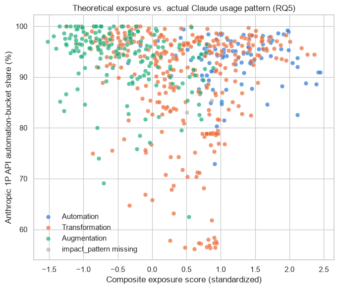

```python
fig, ax = plt.subplots(figsize=(7, 6))
for pattern, color in CATEGORY_COLORS.items():
    subset = rq5[(rq5["impact_pattern"] == pattern) & rq5["anthropic_1p_automation_share"].notna()]
    ax.scatter(
        subset["composite_exposure_score"], subset["anthropic_1p_automation_share"],
        label=pattern, color=color, alpha=0.7, edgecolor="white", linewidth=0.4, s=40,
    )
missing = rq5[rq5["impact_pattern"].isna() & rq5["anthropic_1p_automation_share"].notna()]
if len(missing):
    ax.scatter(
        missing["composite_exposure_score"], missing["anthropic_1p_automation_share"],
        label="impact_pattern missing", color=MISSING_COLOR, alpha=0.5,
        edgecolor="white", linewidth=0.4, s=40,
    )
ax.set_xlabel("Composite exposure score (standardized)")
ax.set_ylabel("Anthropic 1P API automation-bucket share (%)")
ax.set_title("Theoretical exposure vs. actual Claude usage pattern (RQ5)")
ax.legend(frameon=False, loc="best")
plt.tight_layout()
plt.savefig("../outputs/figures/rq5_exposure_vs_anthropic_usage.png", dpi=150)
plt.show()
```

**Reading this section:** two independent real-world signals, tested against the same theoretical `composite_exposure_score`.

**Employment growth (BLS OEWS, 2023→2025):** essentially uncorrelated with `composite_exposure_score` (rho=0.025, p=0.47, n=817). Among the 269 high-exposure occupations with employment data, the split is almost exactly even -- 134 already declining vs. 135 still growing. This is consistent with the caveat above: two years compresses far more than AI adoption into one number (post-pandemic sector recovery, interest-rate-driven hiring/layoffs, demographic shifts, offshoring), and labor markets typically take years to fully reflect a technology shock. A near-zero correlation here does not invalidate the exposure framework; it means the framework is measuring *potential*, not yet-realized displacement -- which is the whole point of framing this as "theoretical exposure vs. realized impact" rather than "predicted vs. actual."

**Anthropic Economic Index usage shares:** here the real result is more interesting, and worth stating plainly rather than left generic. `composite_exposure_score` correlates *negatively* with `anthropic_1p_automation_share` (rho=−0.230, p=1.25e-08, n=598) and *positively*, by the same magnitude, with `anthropic_1p_augmentation_share` (rho=+0.230, same p, same n -- expected, since the two shares are near-complementary). In plain terms: occupations that score HIGHER on the theoretical exposure indices are, in real Claude usage today, more associated with augmentation-style interactions and less with automation-style ones -- the opposite of what a naive "high exposure score = high automation" reading would predict.

A few honest, non-exclusive readings, none confirmed by this data alone: real-world AI use may currently lag the full automation potential the theoretical indices capture; complex, higher-exposure tasks may in practice still benefit more from human-AI collaboration than fully automatable ones do; or there may be a selection effect in which occupations' workers use Claude directly and how. Whichever explanation holds, this is a genuinely useful finding for this project's decision-support framing -- it's a real-world data point *against* the "high theoretical exposure means imminent full automation" narrative, not for it.

Both comparisons are associative, not causal or predictive -- consistent with this project's decision-support framing (evidence → risks → opportunities), never "AI will replace you."

## 8. Student layer — education path vs. exposure

Join O*NET Job Zones (education/experience/training required) to the composite exposure score; aggregate by education level.

```python
JOB_ZONE_LABELS = {
    1: "Zone 1 -- Little or no preparation needed",
    2: "Zone 2 -- Some preparation needed",
    3: "Zone 3 -- Medium preparation needed",
    4: "Zone 4 -- Considerable preparation needed",
    5: "Zone 5 -- Extensive preparation needed",
}

student = master.dropna(subset=["job_zone", "composite_exposure_score"]).copy()
student["job_zone"] = student["job_zone"].round().astype(int).clip(1, 5)
student["job_zone_label"] = student["job_zone"].map(JOB_ZONE_LABELS)

zone_summary = student.groupby(["job_zone", "job_zone_label"]).agg(
    n_occupations=("soc_code", "count"),
    mean_composite_exposure=("composite_exposure_score", "mean"),
    median_composite_exposure=("composite_exposure_score", "median"),
).round(3)
print("=== Composite exposure score by O*NET Job Zone (education/training required) ===")
display(zone_summary)

rho, p = stats.spearmanr(student["job_zone"], student["composite_exposure_score"])
print(f"\nSpearman correlation, job_zone vs. composite_exposure_score: rho={rho:.3f}, p={p:.3g}, n={len(student)}")
```

```
=== Composite exposure score by O*NET Job Zone (education/training required) ===
```

| job_zone | job_zone_label | n_occupations | mean_composite_exposure | median_composite_exposure |
| --- | --- | --- | --- | --- |
| 2 | Zone 2 -- Some preparation needed | 328 | -0.594 | -0.835 |
| 3 | Zone 3 -- Medium preparation needed | 178 | -0.060 | -0.233 |
| 4 | Zone 4 -- Considerable preparation needed | 169 | 0.855 | 0.827 |
| 5 | Zone 5 -- Extensive preparation needed | 123 | 0.569 | 0.761 |

```
Spearman correlation, job_zone vs. composite_exposure_score: rho=0.615, p=2.65e-84, n=798
```

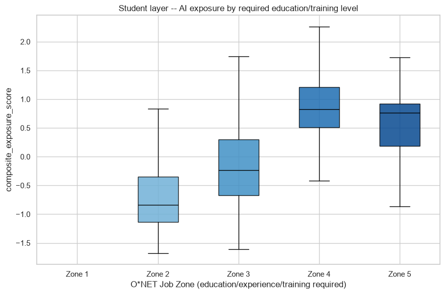

```python
order = [1, 2, 3, 4, 5]
blues = plt.cm.Blues(np.linspace(0.35, 0.9, len(order)))

fig, ax = plt.subplots(figsize=(9, 6))
data_by_zone = [student.loc[student["job_zone"] == z, "composite_exposure_score"].dropna() for z in order]
bp = ax.boxplot(data_by_zone, tick_labels=[f"Zone {z}" for z in order], patch_artist=True, showfliers=False, widths=0.5)
for patch, color in zip(bp["boxes"], blues):
    patch.set_facecolor(color)
    patch.set_alpha(0.85)
for median_line in bp["medians"]:
    median_line.set_color("black")

ax.set_xlabel("O*NET Job Zone (education/experience/training required)")
ax.set_ylabel("composite_exposure_score")
ax.set_title("Student layer -- AI exposure by required education/training level")
plt.tight_layout()
plt.savefig("../outputs/figures/student_layer_jobzone_vs_exposure.png", dpi=150)
plt.show()
```

**Reading this section:** `job_zone` (1-5, O*NET's own scale of education/experience/training required) is aggregated against `composite_exposure_score` to ask a direct question for a student choosing a path: does more required preparation mean more or less AI exposure?

**Real result:** Spearman rho = 0.615, p = 2.65e-84 (n = 798) -- a strong, highly significant *positive* correlation. More required preparation is associated with *more* AI exposure in this dataset, not less:

| Job Zone | n | mean composite exposure | median |
| --- | --- | --- | --- |
| 2 -- Some preparation | 328 | -0.594 | -0.835 |
| 3 -- Medium preparation | 178 | -0.060 | -0.233 |
| 4 -- Considerable preparation | 169 | 0.855 | 0.827 |
| 5 -- Extensive preparation | 123 | 0.569 | 0.761 |

This is consistent with RQ4: reading, writing, critical thinking and similar cognitive/communication skills -- the kind formal education builds -- came back positively (not negatively) associated with exposure there too. Two honest wrinkles worth stating plainly rather than smoothing over: **Zone 1 ("little or no preparation needed") has zero occupations in this table** -- confirmed as a genuine gap in the underlying AIOE/ILO/GPTs-are-GPTs source data this project joins against, not a bug in the join, so the lowest end of the education spectrum simply isn't represented here. And the trend **isn't strictly monotonic**: Zone 5 (extensive/doctoral-level preparation, n=123, std=0.54, well-spread not a few outliers) averages *lower* exposure than Zone 4, a real and modest effect -- plausibly because the most credentialed, licensure-gated occupations (e.g. physicians, judges) resist automation in ways that don't reduce to "more school = more exposure."

As elsewhere in this notebook, an association here is not career destiny for any individual occupation within a zone -- Job Zone is a coarse bucket, and RQ1's per-occupation ranking is the more precise tool for a specific career decision.

## 9. Professional layer — reskilling paths

Occupation-to-occupation skill-vector similarity to surface, for a given high-exposure occupation, the nearest lower-exposure alternatives and the skill gap to close.

```python
# Professional layer -- for a high-exposure occupation, which lower-exposure
# occupations look most similar by REQUIRED SKILL PROFILE (cosine similarity
# over the same 10 O*NET Basic Skills importance ratings RQ4 uses), and what's
# the gap to close to get there. Illustrative similarity search, not a
# validated career-counseling tool.
from sklearn.metrics.pairwise import cosine_similarity

skill_cols = [c for c in master.columns if c.startswith("skill__")]
print(f"Using {len(skill_cols)} O*NET Basic Skills columns: {skill_cols}")


def nearest_lower_exposure_alternatives(source_soc, df, skill_cols, n=5, min_gap=0.0):
    """
    For a given high-exposure occupation (by soc_code), find the n most
    skill-similar occupations (cosine similarity over O*NET Basic Skills
    importance ratings) among those with a MEANINGFULLY lower
    composite_exposure_score -- candidates for reskilling.
    """
    source_rows = df.loc[df["soc_code"] == source_soc]
    if source_rows.empty:
        raise ValueError(f"soc_code {source_soc} not found")
    source_row = source_rows.iloc[0]
    source_vec = source_row[skill_cols].to_numpy(dtype=float)
    source_score = source_row["composite_exposure_score"]

    candidates = df.dropna(subset=skill_cols + ["composite_exposure_score"]).copy()
    candidates = candidates[candidates["soc_code"] != source_soc]
    candidates = candidates[candidates["composite_exposure_score"] < source_score - min_gap]
    if candidates.empty:
        return candidates

    cand_matrix = candidates[skill_cols].to_numpy(dtype=float)
    sims = cosine_similarity(source_vec.reshape(1, -1), cand_matrix)[0]
    candidates = candidates.assign(skill_similarity=sims)
    top = candidates.sort_values("skill_similarity", ascending=False).head(n).copy()

    gap_cols = []
    for col in skill_cols:
        gap_col = f"gap__{col}"
        top[gap_col] = top[col] - source_row[col]
        gap_cols.append(gap_col)

    out_cols = ["soc_code", "occupation_title", "composite_exposure_score", "skill_similarity"] + gap_cols
    return top[out_cols]


eligible = master.dropna(subset=skill_cols + ["composite_exposure_score"])
example_soc = eligible.sort_values("composite_exposure_score", ascending=False).iloc[0]["soc_code"]
example_title = eligible.loc[eligible["soc_code"] == example_soc, "occupation_title"].iloc[0]
print(f"\nExample high-exposure occupation: {example_title} ({example_soc})")

alternatives = nearest_lower_exposure_alternatives(example_soc, master, skill_cols, n=5)
display(alternatives)
```

```
Using 10 O*NET Basic Skills columns: ['skill__active_learning', 'skill__active_listening', 'skill__critical_thinking', 'skill__learning_strategies', 'skill__mathematics', 'skill__monitoring', 'skill__reading_comprehension', 'skill__science', 'skill__speaking', 'skill__writing']

Example high-exposure occupation: Computer Programmers (15-1251)
```

|  | soc_code | occupation_title | composite_exposure_score | skill_similarity | gap__skill__active_learning | gap__skill__active_listening | gap__skill__critical_thinking | gap__skill__learning_strategies | gap__skill__mathematics | gap__skill__monitoring | gap__skill__reading_comprehension | gap__skill__science | gap__skill__speaking | gap__skill__writing |
| --- | --- | --- | --- | --- | --- | --- | --- | --- | --- | --- | --- | --- | --- | --- |
| 460 | 31-9096 | Veterinary Assistants and Laboratory Animal Ca... | -0.793020 | 0.998746 | -0.24 | -0.25 | -0.500 | -0.260 | -0.370 | 0.12 | -0.260 | -0.13 | -0.12 | -0.130 |
| 94 | 15-1221 | Computer and Information Research Scientists | 1.436965 | 0.998447 | 0.38 | 0.00 | 0.250 | 0.620 | 0.260 | 0.12 | 0.370 | 0.37 | 0.38 | 0.130 |
| 415 | 29-2036 | Medical Dosimetrists | 0.310215 | 0.998223 | 0.26 | 0.25 | 0.370 | 0.740 | 0.380 | 0.50 | 0.620 | 0.63 | 0.76 | 0.500 |
| 146 | 17-3027 | Mechanical Engineering Technicians | -0.040171 | 0.998198 | -0.06 | -0.25 | -0.125 | 0.185 | 0.065 | 0.12 | 0.305 | 0.06 | 0.44 | 0.125 |
| 129 | 17-2121 | Marine Engineers and Naval Architects | 0.395087 | 0.998067 | 0.38 | 0.00 | 0.370 | 0.500 | 0.500 | 0.38 | 0.500 | 0.75 | 0.63 | 0.500 |

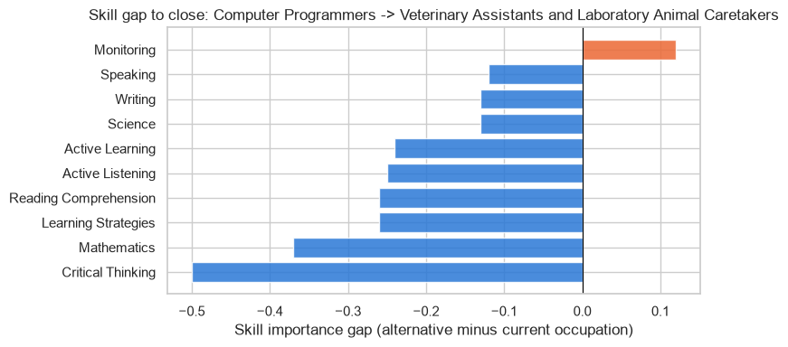

```python
top1 = alternatives.iloc[0]
gap_cols = [c for c in alternatives.columns if c.startswith("gap__")]
gap_series = top1[gap_cols].rename(lambda c: c.replace("gap__skill__", "").replace("_", " ").title())
gap_series = gap_series.sort_values()

colors = ["#2a78d6" if v < 0 else "#eb6834" for v in gap_series.values]

fig, ax = plt.subplots(figsize=(8, max(3, 0.4 * len(gap_series))))
ax.barh(gap_series.index, gap_series.values, color=colors, alpha=0.85)
ax.axvline(0, color="black", linewidth=0.8)
ax.set_xlabel("Skill importance gap (alternative minus current occupation)")
ax.set_title(f"Skill gap to close: {example_title} -> {top1['occupation_title']}")
plt.tight_layout()
plt.savefig("../outputs/figures/professional_layer_skill_gap.png", dpi=150)
plt.show()
```

**Reading this section:** `nearest_lower_exposure_alternatives()` takes one high-exposure occupation and ranks *other* occupations two ways at once: they must score meaningfully lower on `composite_exposure_score`, and among those, they're ranked by cosine similarity of their O*NET Basic Skills importance profile to the source occupation's.

**Real example:** *Computer Programmers* (composite_exposure_score = 2.45, near the top of this dataset). Top-5 lower-exposure alternatives by skill similarity:

| Alternative | composite_exposure_score | skill similarity |
| --- | --- | --- |
| Veterinary Assistants and Laboratory Animal Caretakers | -0.793 | 0.9987 |
| Computer and Information Research Scientists | 1.437 | 0.9984 |
| Medical Dosimetrists | 0.310 | 0.9982 |
| Mechanical Engineering Technicians | -0.040 | 0.9982 |
| Marine Engineers and Naval Architects | 0.395 | 0.9981 |

Read this honestly rather than at face value. The #1 match, Veterinary Assistants, is not an intuitive reskilling path for a programmer -- and that's expected, not a bug: with only 10 generic O*NET Basic Skills to compare (the same Essential-Skills-only scope limitation flagged in RQ4), cosine similarity is matching the *shape* of a fairly generic cognitive/communication skill profile, not vocational specifics like coding ability, domain knowledge, or credentials. Two very different jobs can look alike on 10 broad dimensions without being a real career pivot. The #2 match, Computer and Information Research Scientists, is the one that actually reads as a sensible next step for a programmer -- a genuinely related, lower-exposure specialization -- which is worth pointing out as the entry that *does* validate the method, alongside the one that doesn't.

Same scope caveat as RQ4: this only draws on the 10 O*NET Basic Skills this project fetched, not the full Cross-Functional Skills/Abilities taxonomy, so a close match here means close *within that limited skill set* -- real-world reskilling also depends on credentials, licensure, and experience this similarity search doesn't see at all. Treat this as a starting shortlist to research further and sanity-check by hand, not a finished reskilling plan.

This is a single worked example, not a general finding -- `nearest_lower_exposure_alternatives()` works for any `soc_code`, and a fuller version of this section could let a reader look up their own occupation once this becomes an interactive tool rather than a static notebook cell.

## 10. Appendix — Canada in context

One comparison chart: Statistics Canada's own NOC-based AI exposure estimates against the equivalent global/US-ranked occupations. Not a parallel pipeline (see README guardrails).

```python
# Canada appendix -- Statistics Canada's own NOC-based AI exposure
# estimates, built on the same underlying AIOE index (Felten-Raj-Seamans)
# this project uses at the US SOC level, but aggregated by StatCan into
# 28 broad NOC occupation groups. Loaded standalone via
# load_statcan_noc_exposure() -- NOT joined onto `master` through a
# NOC-to-SOC crosswalk; this is one illustrative comparison, not a
# parallel pipeline (see README/Data-Dictionary guardrails).

from analysis.build_master_dataset import load_statcan_noc_exposure

statcan = load_statcan_noc_exposure()
print(f"=== Statistics Canada Table A.2: {len(statcan)} NOC occupation groups ===")
display(
    statcan[["noc_code", "occupation_group", "Employment", "AIOE", "Complementarity-adjusted AIOE"]]
    .sort_values("AIOE", ascending=False)
)
```

```
=== Statistics Canada Table A.2: 28 NOC occupation groups ===
```

|  | noc_code | occupation_group | Employment | AIOE | Complementarity-adjusted AIOE |
| --- | --- | --- | --- | --- | --- |
| 12 | 11 | Professional occupations in business and finance | 452100 | 6.6595 | 5.8600 |
| 18 | 217 | Computer and information systems professionals | 307600 | 6.5877 | 5.9195 |
| 15 | 41 | Professional occupations in law and social, co... | 364000 | 6.5632 | 5.5925 |
| 23 | 213, 214 | Engineers | 203900 | 6.5441 | 5.6093 |
| 27 | 215, 216 | Architects and statisticians | 41000 | 6.5368 | 5.5940 |
| 2 | 12, 13 | Administrative occupations in finance, insuran... | 961000 | 6.4815 | 5.8056 |
| 8 | 40 | Professional occupations in education services | 643900 | 6.4743 | 5.3975 |
| 0 | 0 | Management occupations | 1401800 | 6.4705 | 5.4581 |
| 26 | 211, 212 | Physical and life science professionals | 53500 | 6.3801 | 5.3913 |
| 25 | 31 | Professional occupations in health (except nur... | 155100 | 6.3060 | 5.1119 |
| 3 | 14, 15 | Office support and co-ordination occupations | 916800 | 6.2339 | 5.7637 |
| 21 | 30 | Professional occupations in nursing | 289000 | 6.1660 | 5.0834 |
| 11 | 22 | Technical occupations related to natural and a... | 460200 | 6.1608 | 5.3268 |
| 5 | 65 | Service representatives and other customer and... | 744800 | 6.0972 | 5.5326 |
| 10 | 64 | Sales representatives and salespersons in whol... | 618600 | 6.0941 | 5.4565 |
| 4 | 62, 63 | Sales and service supervisors | 759000 | 6.0866 | 5.3035 |
| 9 | 42, 43, 44 | Support occupations in law and social services | 624100 | 6.0716 | 5.2256 |
| 17 | 51, 52 | Occupations in art, culture, recreation and sp... | 311500 | 6.0360 | 5.2657 |
| 20 | 32 | Technical occupations in health | 292600 | 5.8853 | 5.0736 |
| 16 | 92, 94 | Machine operators and supervisors in manufactu... | 334100 | 5.7241 | 5.0586 |
| 19 | 34 | Assisting occupations in support of health ser... | 294500 | 5.6644 | 4.9240 |
| 13 | 73 | Maintenance and equipment operation trades | 418400 | 5.6468 | 4.7689 |
| 1 | 66, 67 | Support occupations in sales and service | 1156000 | 5.5916 | 5.1406 |
| 14 | 95, 96 | Assemblers and labourers in manufacturing and ... | 371800 | 5.5876 | 5.0988 |
| 7 | 72 | Industrial, electrical and construction trades | 646100 | 5.5706 | 4.7715 |
| 6 | 74, 75 | Transport and heavy equipment operators and se... | 701400 | 5.5456 | 4.8267 |
| 22 | 8 | Natural resources, agriculture and related pro... | 246000 | 5.4174 | 4.7974 |
| 24 | 76 | Trades helpers, construction labourers and rel... | 174700 | 5.3877 | 4.7027 |

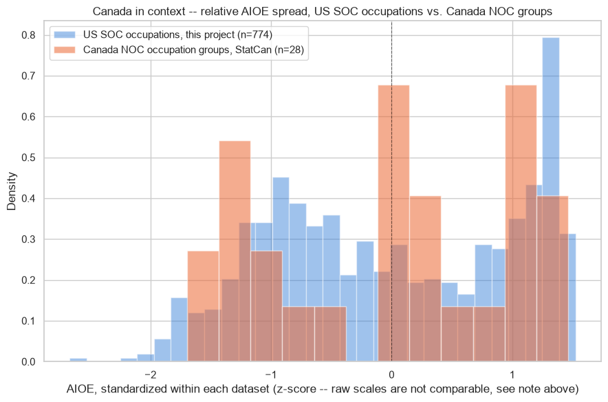

```python
# Both columns are conceptually the same Felten-Raj-Seamans AIOE index,
# but StatCan recomputed it themselves from O*NET v28.2 and report it on
# their own raw scale (confirmed via the source page's own methodology
# note: relative to their sample median, "should not be interpreted in
# absolute terms") -- NOT the z-scored value this project's aioe_score
# already is (confirmed: mean 0, SD 1, directly from AIOE_DataAppendix.xlsx).
# Comparing raw values would be comparing different units under the same
# column name, so both are standardized to their own mean/SD first.
master_aioe = master["aioe_score"].dropna()
master_z = (master_aioe - master_aioe.mean()) / master_aioe.std()

statcan_aioe = statcan["AIOE"].dropna()
statcan_z = (statcan_aioe - statcan_aioe.mean()) / statcan_aioe.std()

fig, ax = plt.subplots(figsize=(9, 6))
ax.hist(
    master_z, bins=30, density=True, alpha=0.45,
    color="#2a78d6", label=f"US SOC occupations, this project (n={len(master_z)})",
)
ax.hist(
    statcan_z, bins=12, density=True, alpha=0.55,
    color="#eb6834", label=f"Canada NOC occupation groups, StatCan (n={len(statcan_z)})",
)
ax.axvline(0, color="black", linewidth=0.8, linestyle="--", alpha=0.5)
ax.set_xlabel("AIOE, standardized within each dataset (z-score -- raw scales are not comparable, see note above)")
ax.set_ylabel("Density")
ax.set_title("Canada in context -- relative AIOE spread, US SOC occupations vs. Canada NOC groups")
ax.legend()
plt.tight_layout()
plt.savefig("../outputs/figures/canada_appendix_aioe_comparison.png", dpi=150)
plt.show()
```

**Reading this section:** the table ranks StatCan's 28 NOC occupation groups by their own `AIOE` value. Top: *Professional occupations in business and finance* (6.66), *Computer and information systems professionals* (6.59), *Professional occupations in law and social, community and government services* (6.56). Bottom: *Trades helpers, construction labourers and related occupations* (5.39), *Natural resources, agriculture and related production occupations* (5.42), *Transport and heavy equipment operators and servicers* (5.55) -- a familiar white-collar-vs-manual split, consistent with the pattern this project finds elsewhere.

**Important scale caveat, confirmed from the source itself:** StatCan's `AIOE` column and this project's own `aioe_score` are conceptually the same Felten-Raj-Seamans (2021) index, but are **not on the same numeric scale**. StatCan recomputed it themselves from O*NET v28.2 and report it as a raw value relative to their own sample's median (~6.0 here) -- their own methodology note states it explicitly: *"should not be interpreted in absolute terms."* This project's `aioe_score`, by contrast, comes directly from the original authors' published `AIOE_DataAppendix.xlsx`, which is already a z-score (confirmed: mean ≈ 0, SD = 1, n = 774 US SOC occupations). A raw-value overlay of the two would have been comparing different units under the same column name -- so the chart above standardizes **both** to their own mean/SD before overlaying, comparing the *shape* of relative exposure spread rather than raw magnitude.

## 11. Summary & what this means for you

Decision-support framing only — evidence, risks, opportunities, skills, and alternatives; never a single prescriptive recommendation. Sets up the Phase 2 web app's dashboard fields (see the Data Dictionary's "Phase 2 Tool Design" tab).

```python
# Cross-checks each Phase 2 dashboard dimension (Data Dictionary's "Phase 2
# Tool Design" tab) against what this notebook's master table actually has,
# so Phase 2 starts from an honest picture of what's ready vs. still needs
# fetching -- not an assumption.
dashboard_readiness = pd.DataFrame([
    {"dimension": "AI Exposure (composite)", "source": "composite_exposure_score",
     "status": "Ready" if "composite_exposure_score" in master.columns else "Missing",
     "backed_by": "RQ1"},
    {"dimension": "Task Automation share", "source": "ILO task-level data",
     "status": "Ready" if "ilo_task_mean" in master.columns else "Missing",
     "backed_by": "RQ3 (load_ilo_task_detail)"},
    {"dimension": "Impact Pattern", "source": "impact_pattern",
     "status": "Ready, with caveat" if "impact_pattern" in master.columns else "Missing",
     "backed_by": "RQ2 -- doesn't yet predict real usage share cleanly"},
    {"dimension": "Human interaction requirement", "source": "O*NET Social Skills / Work Activities",
     "status": "Not yet fetched", "backed_by": "-- Essential Skills.xlsx covers Basic Skills only"},
    {"dimension": "Physical requirements", "source": "O*NET Physical Abilities / Work Context",
     "status": "Not yet fetched", "backed_by": "-- not fetched this pass"},
    {"dimension": "Analytical requirements", "source": "O*NET Cognitive Abilities",
     "status": "Partial proxy only",
     "backed_by": "RQ4 -- 3 of 10 Basic Skills touch this (critical_thinking, mathematics, science), not the real Cognitive Abilities category"},
    {"dimension": "Current employment & wage", "source": "BLS OEWS",
     "status": "Employment ready, wage missing" if "tot_emp_2025" in master.columns else "Missing",
     "backed_by": "RQ5 -- employment counts + growth rate only, no wage figures fetched"},
    {"dimension": "Required education/experience/training", "source": "O*NET Job Zones",
     "status": "Ready" if "job_zone" in master.columns else "Missing",
     "backed_by": "Student layer"},
    {"dimension": "Key current skills", "source": "O*NET Skills (top importance-ranked)",
     "status": "Partial -- Basic Skills only (10 of O*NET's full taxonomy)",
     "backed_by": "RQ4, Professional layer"},
    {"dimension": "Nearest lower-exposure occupations + skill gap", "source": "O*NET skill-similarity calc",
     "status": "Ready", "backed_by": "Professional layer (nearest_lower_exposure_alternatives)"},
])
print("=== Phase 2 dashboard dimensions vs. what this notebook's master table actually has ===")
display(dashboard_readiness)

n_ready = dashboard_readiness["status"].str.startswith("Ready").sum()
print(f"\n{n_ready} of {len(dashboard_readiness)} dashboard dimensions are fully ready; the rest need more O*NET categories fetched before Phase 2 build starts.")
```

```
=== Phase 2 dashboard dimensions vs. what this notebook's master table actually has ===
```

|  | dimension | source | status | backed_by |
| --- | --- | --- | --- | --- |
| 0 | AI Exposure (composite) | composite_exposure_score | Ready | RQ1 |
| 1 | Task Automation share | ILO task-level data | Ready | RQ3 (load_ilo_task_detail) |
| 2 | Impact Pattern | impact_pattern | Ready, with caveat | RQ2 -- doesn't yet predict real usage share cl... |
| 3 | Human interaction requirement | O*NET Social Skills / Work Activities | Not yet fetched | -- Essential Skills.xlsx covers Basic Skills only |
| 4 | Physical requirements | O*NET Physical Abilities / Work Context | Not yet fetched | -- not fetched this pass |
| 5 | Analytical requirements | O*NET Cognitive Abilities | Partial proxy only | RQ4 -- 3 of 10 Basic Skills touch this (critic... |
| 6 | Current employment & wage | BLS OEWS | Employment ready, wage missing | RQ5 -- employment counts + growth rate only, n... |
| 7 | Required education/experience/training | O*NET Job Zones | Ready | Student layer |
| 8 | Key current skills | O*NET Skills (top importance-ranked) | Partial -- Basic Skills only (10 of O*NET's fu... | RQ4, Professional layer |
| 9 | Nearest lower-exposure occupations + skill gap | O*NET skill-similarity calc | Ready | Professional layer (nearest_lower_exposure_alt... |

```
5 of 10 dashboard dimensions are fully ready; the rest need more O*NET categories fetched before Phase 2 build starts.
```

### What the evidence actually shows

No single finding in this notebook supports a blanket "AI will/won't take your job" story -- the honest picture is several real, sometimes surprising patterns that only emerged by checking the theoretical indices against real-world data rather than trusting them at face value:

**More education is associated with *more* exposure here, not less** -- the student layer found a strong positive correlation (Spearman rho = 0.615, p = 2.65e-84) between O*NET Job Zone (required education/training) and exposure, consistent with RQ4's finding that reading, writing, critical thinking and similar skills formal education builds are all *positively* associated with high exposure (all 10 tested Basic Skills, none negative). This runs against a simple "stay in school to be safe" narrative. Two caveats carry real weight here: Job Zone 1 (least preparation) has zero occupations in this dataset (a genuine coverage gap in the underlying indices, not a bug), and Zone 5 (the most credentialed, licensure-gated occupations) breaks the trend with lower average exposure than Zone 4 -- a real, modest effect plausibly tied to licensure and judgment requirements rather than education level itself.

**No protective skill was found -- and that's a scope limitation, not a real absence.** RQ4 tested the only 10 skills this project fetched (O*NET's Basic Skills category) and found every one positively associated with high exposure. That is very likely because Essential Skills.xlsx never covered O*NET's separate Cross-Functional Skills category (Complex Problem Solving, Technical Skills, Resource Management, Social Skills) -- those files were never fetched this pass, so this project cannot yet say whether a genuinely protective skill exists in the fuller O*NET taxonomy. The professional layer's skill-similarity search inherits the same limitation: its top match for a real example (Computer Programmers) was a poor intuitive fit (Veterinary Assistants), because only 10 generic skills are being compared -- while its #2 match (Computer and Information Research Scientists) was a genuinely sensible reskilling step, showing the method has real value even while its narrow skill scope makes it noisy.

**Canada's own pattern broadly echoes the US one, once compared honestly.** StatCan's NOC-group AIOE ranking topped by *Professional occupations in business and finance* (6.66) and bottomed by *Trades helpers, construction labourers* (5.39) reflects the same white-collar-vs-manual split this project finds throughout -- but StatCan computed AIOE on their own raw scale (median ~6.0), not the z-scored value this project uses, so the two are only comparable after standardizing each to its own distribution, not by raw number. A reminder that even two datasets built on the same named methodology can carry incompatible units.

### What this means for you -- evidence and options, not a verdict

Per this project's guiding principle (see `README.md`), nothing here is a single prescriptive recommendation -- these are starting points to investigate further, not conclusions to act on directly.

**If you're choosing a field of study:** required education level tracks *with*, not against, exposure in this dataset -- so "pick something requiring more school" is not, by itself, a risk-reduction strategy here. RQ1's own per-occupation ranking (not the 5-bucket Job Zone average) is the more precise tool for comparing specific fields, and the task-level view in RQ3 is worth checking for any specific occupation under consideration, since two occupations with similar averages can have very different internal task mixes.

**If you're in a high-exposure occupation and considering a change:** the professional layer's `nearest_lower_exposure_alternatives()` function is a genuine starting shortlist, not a finished plan -- sanity-check every suggestion by hand, since it only sees 10 generic skills and knows nothing about credentials, licensure, or your own actual experience. Try it on your own `soc_code` in the cell above rather than relying on the one worked example here.

**Known limitations to carry into Phase 2** (see the dashboard-readiness table above): three of the ten planned dashboard dimensions (human interaction requirement, physical requirements, a real analytical-requirements measure) need O*NET categories this project hasn't fetched yet, and wage data was never fetched from BLS OEWS alongside the employment counts. Phase 2 should either fetch these before launch or clearly mark those dashboard fields as "coming soon" rather than silently omitting them.